# California Annual Fires From 2012 to 2016

Hanh Ngyuen and Kim Santos

# Introduction

This project takes a look into the years 2012-2016 of California’s wild fires and is broken into three sections to investigate the annual yearly fires, climate change and yearly burned acres through descriptive and inferential statistics.

### **Yearly Fires From 2012 to 2016**

The ‘Fires Yearly’ data set was created by collecting information from the California Government Cal Fires website. The values from the following two links were merged by taking the average of the two values of each year from 2012 to 2016.

http://cdfdata.fire.ca.gov/incidents/incidents_statsevents

http://calfire.ca.gov/downloads/redbooks/2015_Redbook/2015_Redbook_Graphs-Charts.pdf

```r
setwd("~/Excel Documents")
library("readxl")
fire <- read_excel("Fires Yearly.xlsx")
head(fire)
```

```
## # A tibble: 5 x 2
##    Year Fires
##   <dbl> <dbl>
## 1  2012  2922
## 2  2013  3672
## 3  2014  2920
## 4  2015  4187
## 5  2016  5762
```

#### **A.** We will calculate the mean of the total fires from the years 2012-2016 in order to get an idea what the fire average occurred in the past 5 years.

```r
yearly_fires <- c(2922, 3672, 2920, 4187, 5762)
mean(yearly_fires)
```

```
## [1] 3892.6
```

#### **B.** In case outliers were used when calculating the mean, the median can help determine a more decisive answer. The outliers can influence the results whereas the median has a less likely chance to have outliers.

```r
median(yearly_fires)
```

```
## [1] 3672
```

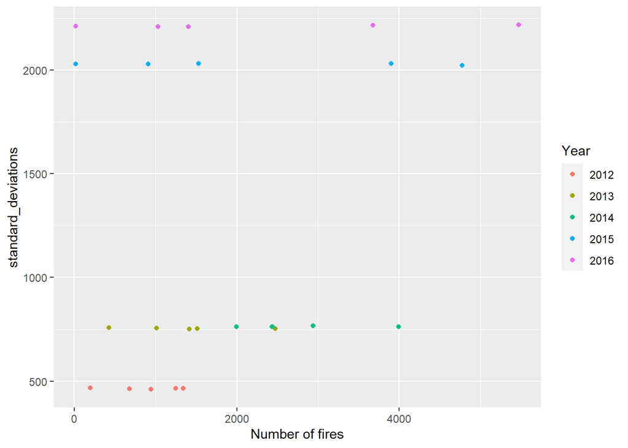

```r
library("ggplot2")
N <- 5

g1 <- runif(N, 0, 2000)
g2 <- runif(N, 0, 3000)
g3 <- runif(N, 0, 4000)
g4 <- runif(N, 0, 5000)
g5 <- runif(N, 0, 6000)

sd1 <- sd(g1)
sd2 <- sd(g2)
sd3 <- sd(g3)
sd4 <- sd(g4)
sd5 <- sd(g5)


df1 <- data.frame(g1, sd1, "2012")
df2 <- data.frame(g2, sd2, "2013")
df3 <- data.frame(g3, sd3, "2014")
df4 <- data.frame(g4, sd4, "2015")
df5 <- data.frame(g5, sd5, "2016")

names(df1) <- c("xdata", "standard_deviations", "Year")
names(df2) <- c("xdata", "standard_deviations", "Year")
names(df3) <- c("xdata", "standard_deviations", "Year")
names(df4) <- c("xdata", "standard_deviations", "Year")
names(df5) <- c("xdata", "standard_deviations", "Year")
main_df <- rbind(df1, df2, df3, df4, df5)

ggplot(main_df, aes(x = xdata, y = standard_deviations, color = Year)) +
  geom_jitter() +
  xlab("Number of fires")
```

### **Climate Change**

The ‘Climate Change’ data set was collected from the official National Centers of Environmental Information website. Recordings of the the annual average California surface temperature can be found here:

https://www.ncdc.noaa.gov/cag/time-series/us/4/0/tavg/ytd/12/2012-2017?base_prd=true&firstbaseyear=2012&lastbaseyear=2017

This section will analyze how California’s climate has changed in the past 5 years.

```r
setwd("~/Excel Documents")
climate_change <- read_excel("climate change.xlsx")
head(climate_change)
```

```
## # A tibble: 5 x 2
##    Year `Temperature °F`
##   <dbl>            <dbl>
## 1  2012             59.9
## 2  2013             59.3
## 3  2014             61.5
## 4  2015             60.8
## 5  2016             60.2
```

#### **A.** The correlation in climate change can show the association between the temperatures and years

```r
cor(climate_change$Year, climate_change$`Temperature ˚F`)
```

```
## [1] 0.3932281
```

#### **B.** Average Annual California Temperatures Graph using regression.

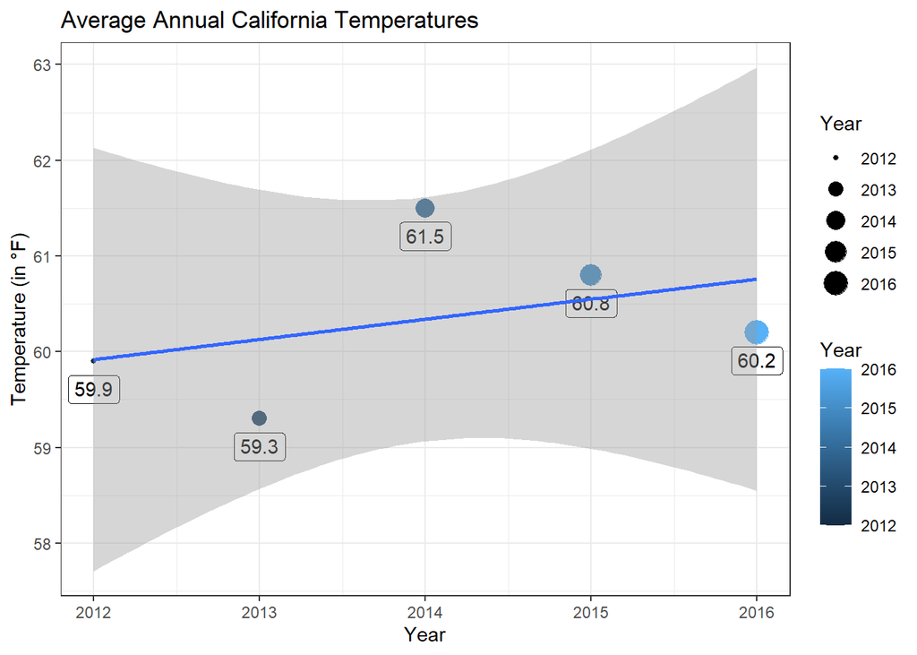

```r
library("ggplot2")
baseplot <- ggplot(climate_change, aes(x = Year , y = `Temperature ˚F`)) +
  geom_point(aes(color = Year, size = Year)) +
  geom_label(aes(label = `Temperature ˚F`), vjust = 1.5) +
  ggtitle("Average Annual California Temperatures") +
  ylab("Temperature (in ˚F)")

#regression line
baseplot +
  geom_smooth(method = "lm", se = TRUE) +
  theme_bw(); #removes gray background
```

#### **C.** Annual Number of Fires in California Graph using the regression line.

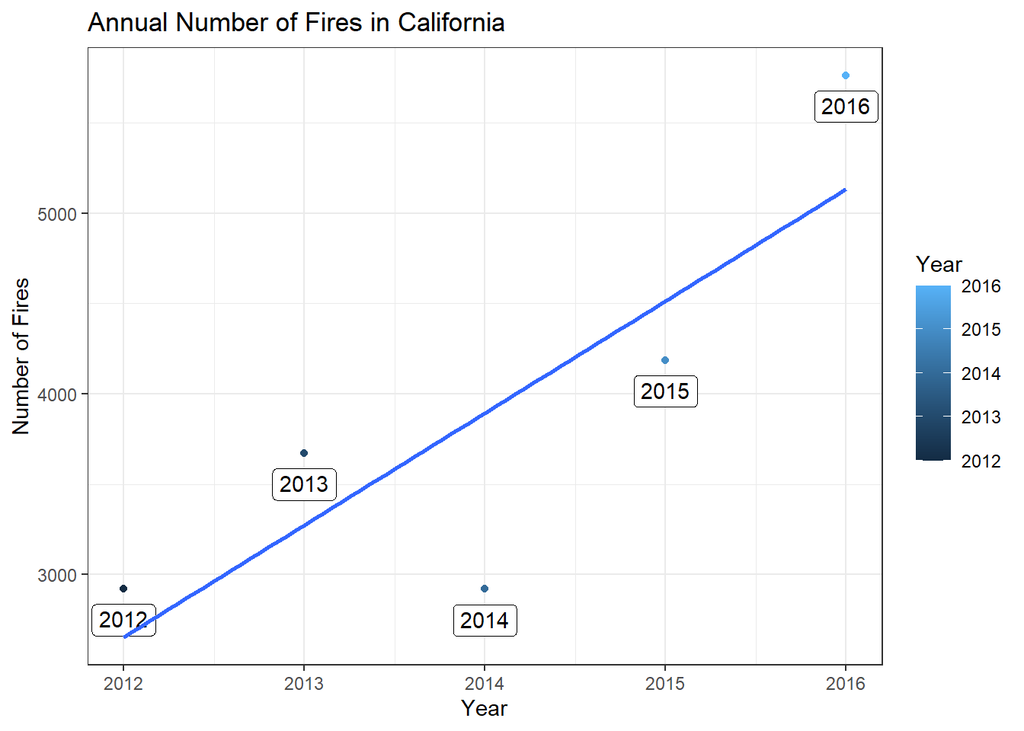

```r
 library("ggplot2")
baseplot <- ggplot(fire, aes(x = Year, y = Fires)) +
  geom_point(aes(color = Year)) +
  geom_label(aes(label = Year), vjust = 1.5) +
  ggtitle("Annual Number of Fires in California") +
  ylab("Number of Fires")
#regression line
baseplot +
  geom_smooth(method = "lm", se = FALSE) +
  theme_bw()
```

#### **Doing Geometric Distribution.**

##### Define p of the chance of a cool day in a randomly day in Los Angeles

```r
p <- 140 / 365
```

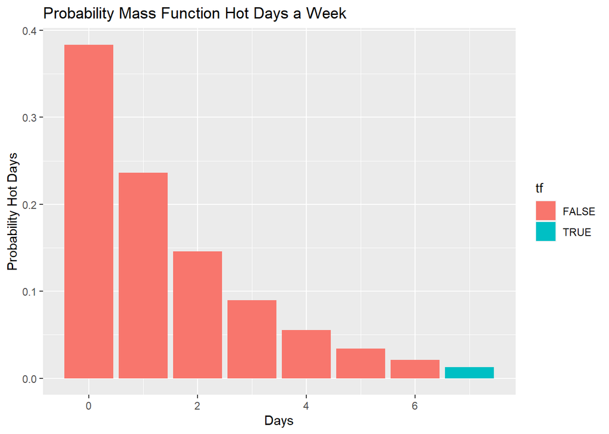

```r
library("ggplot2")
kvals <- 0:7

pmf <- dgeom(kvals, p)
tf <- kvals ==7

df <- data.frame(kvals, pmf, tf)

ggplot(df, aes(x = kvals, y = pmf, fill = tf)) +
  geom_bar(stat = "identity") +
  ggtitle("Probability Mass Function Hot Days a Week") +
  xlab("Days") +
  ylab("Probability Hot Days")
```

### **Acres Burned Yearly**

The ‘Acres Burned Yearly’ data set was collected from the official California Government Cal Fires website. The values from these two links were merged by taking the average of the two values. http://cdfdata.fire.ca.gov/incidents/incidents_statsevents http://calfire.ca.gov/downloads/redbooks/2015_Redbook/2015_Redbook_Graphs-Charts.pdf

```r
setwd("~/Excel Documents")
acres_burned <- read_excel("acres burned yearly.xlsx")
head(acres_burned)
```

```
## # A tibble: 5 x 2
##    Year `Acres Burned`
##   <dbl>          <dbl>
## 1  2012         128956
## 2  2013         114473
## 3  2014         163067
## 4  2015         299421
## 5  2016         196796
```

#### Regression line with standard errors

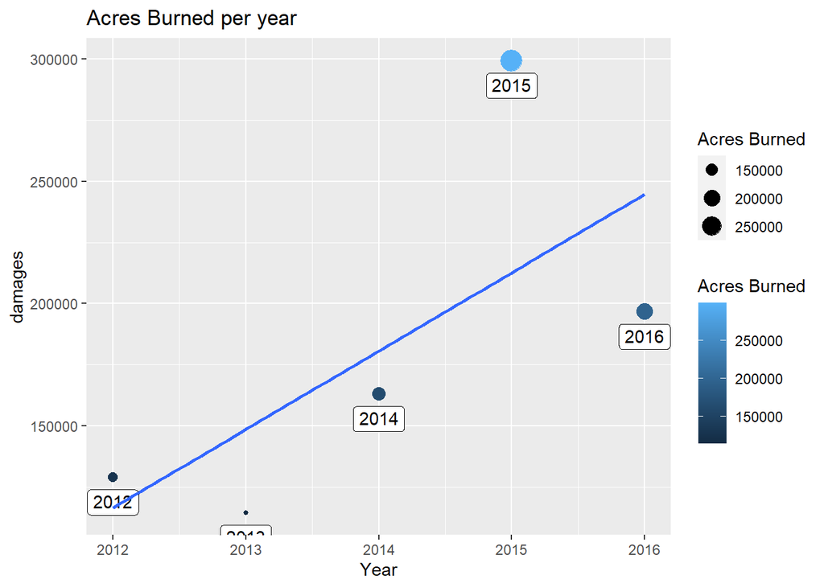

```r
baseplot <- ggplot(acres_burned, aes(x = Year, y = `Acres Burned`)) +
 geom_point(aes(color = `Acres Burned`, size = `Acres Burned`)) +
 geom_label(aes(label = Year), vjust = 1.5) +
 ggtitle("Acres Burned per year") +
 ylab("damages") +
 xlab("Year")

baseplot +
 geom_smooth(method = "lm", se = FALSE)
```

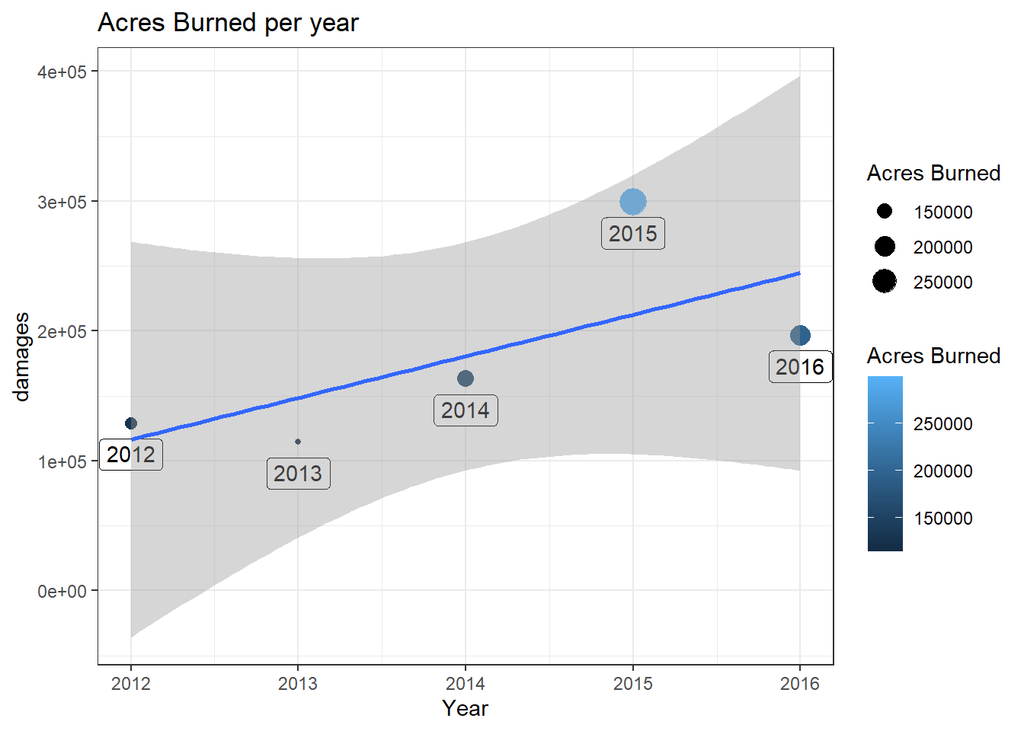

```r
baseplot +
 geom_smooth(method = "lm", se = TRUE) +
 theme_bw() #removes gray background
```

It is observed with the trendline on this graph that the acres burned yearly due to fires has increased between 2012-2016.

#### Calculating acres burned yearly.

```r
acres_burned <- c(128956, 114473, 163067, 299421, 196796)
mean(acres_burned)
```

```
## [1] 180542.6
```

#### Confidence intervals

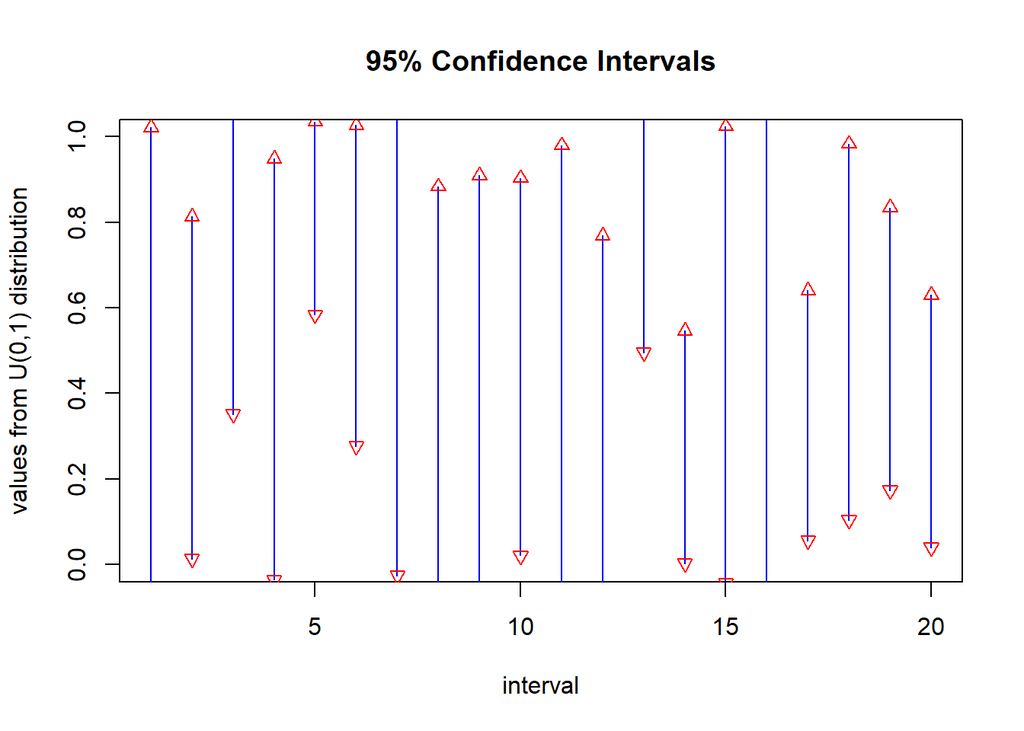

```r
# Constants
confidence <- 95
alpha <- 1 - confidence/100
mu <- mean(acres_burned) #population mean
n <-  4#sample size
N <- 20 #number of iterations

# Base plot
plot(c(1,N), c(0, 1),
    col = "white",
    main = "95% Confidence Intervals",
    xlab = "interval",
    ylab = "values from U(0,1) distribution")

# This vector will collect TRUE/FALSE values about containing the population mean
CI_tracker <- rep(TRUE, N)

# For Loop
for(i in 1:N){
 this_sample <- runif(n)
 xbar <- mean(this_sample)
 s <- sd(this_sample)

 #margin of error
 E <- qt(1 - alpha/2, df = n - 1)*s/sqrt(n)

 #confidence interval
 low <- xbar - E
 high <- xbar + E

 #plotting elements
 lines(c(i,i), c(low, high), col = "blue")
 points(i, low,  col = "red", pch = 6)
 points(i, high, col = "red", pch = 2)

 #Finally, we check if the current confidence interval
 #contains the true population mean
 CI_tracker[i] <- low < mu && mu < high
}
```